## MHD Project (in z)

I have to solve for $B_r$ and $B_{\phi}$ in z.(neglect the r derivatives and $\alpha$ term in the induction equation) I'm using the unitless equation which we findout in Assignment-3 Induction equation is following $$\frac{\partial B_r}{\partial t}=-\frac{V_r}{r}\frac{\partial }{\partial r}(r*B_r)+\frac{\partial }{\partial z}(V_z*B_r)-\frac{\partial }{\partial z}(\alpha*B_{\phi})+\eta_t(\frac{\partial }{\partial r}(\frac{\partial }{r \partial r}(r B_{\phi}))+\frac{\partial^2 B_r}{\partial z ^2})$$ $$\frac{\partial B_{\phi}}{\partial t}=-q\Omega B_r-\frac{\partial }{\partial r}(V_r*B_{\phi})+\frac{\partial }{\partial z}(V_z*B_{\phi})-\frac{\partial }{\partial z}(\alpha*B_r)+\eta_t(\frac{\partial }{\partial r}(\frac{\partial }{r \partial r}(r B_{\phi}))+\frac{\partial^2 B_r}{\partial z ^2})$$ Now the equation consider for the task three is (Only in z derivatives are consider and Velocity term is not taken) $$\frac{\partial B_r '}{\partial t'}=-\frac{\partial (\alpha ' B_{\phi}')}{\partial z'}+\frac{\partial^2 B_r'}{\partial z ^{'2}}$$ $$\frac{\partial B_{\phi}'}{\partial t'}=-q\Omega ' B_{r} ' -\frac{\partial (\alpha ' B_{r}')}{\partial z'}+\frac{\partial^2 B_{\phi} '}{\partial z^{'2} }$$ Now take the Dynamo number equation as $$D=-\frac{q\Omega \alpha _0 h^3}{\eta _t^2}$$ which gives under the unitless equation becomes $\alpha$ changes as $\alpha '$=$\alpha$ $ t_0 $ /$h_0$ (where $t_0=h_0^2/ \eta _t$ ) and the $\Omega$ as $\Omega '$=$\Omega$ *$\frac{h^2}{\eta_t} $ using this
Now the equation consider for the $\alpha -\Omega $ Dynamo is (in unitless form is) $$\frac{\partial B_r '}{\partial t'}=-\alpha_0'\frac{\partial (\alpha(z) ' B_{\phi}')}{\partial z'}+\frac{\partial^2 B_r'}{\partial z ^{'2}}$$ $$\frac{\partial B_{\phi}'}{\partial t'}=\frac{D}{\alpha_0 '} B_{r} '+\frac{\partial^2 B_{\phi} '}{\partial z^{'2} }$$ and the equation consider for the $\alpha^2 $ Dynamo is (in unitless form is) $$\frac{\partial B_r '}{\partial t'}=-\frac{\partial (\alpha ' B_{\phi}')}{\partial z'}+\frac{\partial^2 B_r'}{\partial z ^{'2}}$$ $$\frac{\partial B_{\phi}'}{\partial t'}=\frac{\partial (\alpha ' B_{r}')}{\partial z'}+\frac{\partial^2 B_{\phi} '}{\partial z^{'2} }$$

# Task-3

I am solving this equation in z and the D ,$\alpha$ are all function of r only.Therefore its a fixed constant for fixed r.Thus I will keep this values as constant real number which I will change depending upon the value of r.I will try to vary the value of D for which the deacy constant changes its sign from negative to positive(means growth rate).This D value is known as crtical dynamo number.  
Here since in general case of galaxies,$\Omega$ dreceases with r.So,q>0 and the D < 0 for galaxies.

```python
# importing the required libraries
import math
import numpy as np
import matplotlib.pyplot as plt
from tqdm import tqdm
```

```python
# spatial derivative function using 6th order finite difference method.

def ddBrdz(B,dz,Nz):
    Br = np.zeros((Nz))
    for i in range(3,Nz-4):
        Br[i]=(2*B[i-3,0]-27*B[i-2,0]+270*B[i-1,0]-490*B[i,0]+270*B[i+1,0]-27*B[i+2,0]+2*B[i+3,0])/(180*dz**2)
        #Br[i]=(B[i-1,0]+(-2*B[i,0])+B[i+1,0])/(dz*dz)
    return Br
def ddBphidz(B,dz,Nz):
    Bphi = np.zeros((Nz))
    for i in range(3,Nz-4):
        Bphi[i]=(2*B[i-3,1]-27*B[i-2,1]+270*B[i-1,1]-490*B[i,1]+270*B[i+1,1]-27*B[i+2,1]+2*B[i+3,1])/(180*dz**2)
        #Bphi[i]=(B[i-1,1]+(-2*B[i,1])+B[i+1,1])/(dz*dz)
    return Bphi

def dfdz(f,dz,Nz):
    Br = np.zeros((Nz))
    for i in range(3,Nz-4):
        Br[i]=(-f[i-3]+9*f[i-2]-45*f[i-1]+45*f[i+1]-9*f[i+2]+f[i+3])/(60*dz)
        #Br[i]=(f[i-1]+(-2*f[i])+f[i+1])/(dz*dz)
    #print(Br)
    return Br
```

```python
# dB_r/dt=f1()
# dB_phi/dt=f2()
def alphafn(z):
    return np.sin(np.pi*z)
    #return z
def f1(B,z,alpha,dz,Nz,D):
    return (ddBrdz(B,dz,Nz)-alpha*dfdz(alphafn(z)*B[:,1],dz,Nz))
def f2(B,z,alpha,dz,Nz,D):
    #return (ddBphidz(B,dz,Nz)+alpha*dfdz(alphafn(z)*B[:,0],dz,Nz))
    if D==0:
        return (ddBphidz(B,dz,Nz)+alpha*dfdz(alphafn(z)*B[:,0],dz,Nz))
    else:
        return (ddBphidz(B,dz,Nz)+(D/alpha)*B[:,0])
```

```python
#We use the unitless calculations
#Here so in unitless equation  qΩ = - D/α
# α_0 the amplitude of the α effect and D is the dynamo number (q > 0 if Ω decreases with r, which is generally the case in galaxies, so D < 0.)

T = 130.0  # Total simulation time with respect to t_f
Nz = 57  # Number of spatial grid points
Nt = 600000  # Number of time steps
z_i = -1.12 # start of spatial region in z
z_f = 1.12  # end of spatial domain in z
# z_i = -1.02 # start of spatial region in z
# z_f = 1.02 # end of spatial domain in z
#dz = (z_f - z_i) / (Nz - 1)  # Spatial step size
dz=0.04
# dz = (z_f - z_i) / (Nz - 1)  # Spatial step size
dt = T / Nt  # Time step size


# creating the mesh of z (discetizing the z axis within our region with each distance as dx)
# z = np.linspace(z_i, z_f, Nz)
z = np.zeros((Nz))
for i in range(0,Nz):
    z[i]=z_i+i*dz
t = np.linspace(0, T, Nt+1)
# Now creating the B array with first component is z position value and second compenent is defingin the r (0),phi(1) and intial we make this zero array values
B = np.zeros((Nz, 2))
#B[:,0] is Br component value
#B[:,1] is Bphi component value

#iterations_to_save=[int(Nt/7),int(Nt/4),int(Nt/3),int(Nt/2),int(Nt/1.7),int(Nt/1.4),int(Nt/1.2),Nt]
#iterations_to_save=[53646*5,36338*10,46653*5,56846*5,67230*5,75923*5,83615*5,91307*5]
iterations_to_save=[int(30*Nt/130),int(48*Nt/130),int(54*Nt/130),int(60*Nt/130),int(70*Nt/130),int(80*Nt/130),int(90*Nt/130),int(100*Nt/130),int(110*Nt/130),int(120*Nt/130),Nt]
B_time = np.zeros((Nt+1, 1))
B_pitch=[]
B_list= []
```

```python
print(len(B_list))
```

```
0
```

```python
# Now applying the Intial values for the B_r0 and B_phi0

def intials():
    def B_phi0(r, phi, z):
        #return (np.sin((np.pi * z) / 1.0)+np.cos((np.pi * z) / 2.0))
        return (np.sin((np.pi * z)))

    def B_r0(r, phi, z):
        return 0
        #return ((np.cos((np.pi * z) / 2.0))+(np.sin((np.pi * z)))+1/2*np.sin(4*(np.pi * z)))
    # B_r- intial values are
    B[:, 0] = B_r0(0, 0, z)
    # B_phi- intial values are
    B[:, 1] = B_phi0(0,0,z)

#Boundary condition
a=0  #B_r at Z=Z_i
b1=0  #B_r at Z=Z_f
c=0  #B_phi at Z=Z_i
d1=0  #B_phi at Z=Z_f

# Create arrays to store the solution in time
#iterations_to_save=[0,60,600,int(Nt/8),int(Nt/4),int(Nt/2),Nt]

if 0 in iterations_to_save:
    B_list.append(np.copy(B))
```

```python
#def run(B,iterations_to_save,dz,Nz,alpha):
def run(B,iterations_to_save,B_list,B_time,B_pitch,dz,Nz,alpha,D):
    intials()
    B_list.clear()
    if 0 in iterations_to_save:
        B_list.append(np.copy(B))

    B_pitch.clear()
    for n in tqdm(range(0, Nt + 1)):
        #Now using Runge-Kutta 4th order integration for B_r in time at z
        w=np.zeros((Nz))
        w[:]=dz
        Temp= np.zeros((Nz, 2))
        k1 = f1(B,z,alpha,dz,Nz,D)
        k11 = (f2(B,z,alpha,dz,Nz,D))
        Temp[:,0]=k1*dt/2
        Temp[:,1]=k11*dt/2
        k2 = f1(B+Temp,z,alpha,dz,Nz,D)
        k22 = (f2(B+Temp,z,alpha,dz,Nz,D))
        Temp[:,0]=k2*dt/2
        Temp[:,1]=k22*dt/2
        k3 = (f1(B+Temp,z,alpha,dz,Nz,D))
        k33 = (f2(B+Temp,z,alpha,dz,Nz,D))
        Temp[:,0]=k3*dt
        Temp[:,1]=k33*dt
        k4 = (f1(B+Temp,z,alpha,dz,Nz,D))
        k44 = (f2(B+Temp,z,alpha,dz,Nz,D))
        B[:, 0] = B[:, 0] + ((dt / 6.0) * (k1 +( 2 * k2) + (2 * k3) + k4))
        # Runge-Kutta 4th order integration for B_phi in time at  fixed z
        B[:, 1] = B[:, 1] + ((dt / 6.0) * (k11 + (2 * k22) + (2 * k33) + k44))


        B_time[(n)]=np.log10(np.sqrt((np.mean(B[:,0]))**2+(np.mean(B[:,1]))**2))


        #ghost zones on the outer points of Boundary points(Anti Symmetric Ghost Zone)
        #012 - boundary(3) -456
        #Nz-1,Nz-2,Nz-3- boundary(Nz-4) -Nz-5,Nz-6,Nz-7

        # 3 and Nz-4 are boundary points

        B[3,1]=c
        B[3,0]=a
        B[Nz-4,0]=b1
        B[Nz-4,1]=d1

        B[Nz-1,0]=b1-B[Nz-7,0]
        B[Nz-1,1]=d1-B[Nz-7,1]

        B[Nz-2,0]=b1-B[Nz-6,0]
        B[Nz-2,1]=d1-B[Nz-6,1]

        B[Nz-3,0]=b1-B[Nz-5,0]
        B[Nz-3,1]=d1-B[Nz-5,1]

        B[0,0]=a-B[6,0]
        B[0,1]=c-B[6,1]

        B[1,0]=a-B[5,0]
        B[1,1]=c-B[5,1]

        B[2,0]=a-B[4,0]
        B[2,1]=c-B[4,1]
        #print(B)
        if n in iterations_to_save:
            B_list.append(np.copy(B))
            #B_pitch.append(np.copy(B))
```

```python
# plotting the results
def plot(iterations_to_save,B_list,B_time,B_pitch,Nz):
    m, b = np.polyfit(t[int(Nt/2):Nt], B_time[int(Nt/2):Nt], 1)
    print("The Decay rate is",m*np.log(10))

    fig, ax = plt.subplots(1, 1, figsize=(6, 4))
    for iteration in range(len(iterations_to_save)):
        ax.plot(z[3:Nz-3], B_list[iteration][3:Nz-3, 0], label=f't={iterations_to_save[iteration] * dt:.1f}')
        #ax.plot(z[3:Nz-3], B_list[iteration][3:Nz-3, 0])
    ax.set_xlabel(r'$z/h_0$')
    ax.set_ylabel(r'$B_r(z)/B_0$')
    ax.legend()
    plt.show()

    fig, ax = plt.subplots(1, 1, figsize=(6, 4))
    for iteration in range(len(iterations_to_save)):
        ax.plot(z[3:Nz-3], B_list[iteration][3:Nz-3, 1], label=f't={iterations_to_save[iteration] * dt:.1f}')
        #ax.plot(z[3:Nz-3], B_list[iteration][3:Nz-3, 1])
    ax.set_xlabel(r'$z/h_0$')
    ax.set_ylabel(r'$B_{\phi}(z)/B_0$')
    ax.legend()
    plt.show()

    fig, ax = plt.subplots(1, 1, figsize=(6, 4))
    for iteration in range(len(iterations_to_save)):
        ax.plot(z[3:Nz-3],(B_list[iteration][3:Nz-3, 1]**2+B_list[iteration][3:Nz-3,0]**2), label=f't={iterations_to_save[iteration] * dt:.4f}')
    ax.set_xlabel(r'$z/h_0$')
    ax.set_ylabel(r'$(B_{net}(z)/B_0)^2$')
    ax.legend()
    plt.show()

    B_pitch = np.zeros((Nz-1, len(iterations_to_save)))
    for iteration in range(len(iterations_to_save)):
        for i in range(2,Nz-2):
            B_pitch[i,iteration]=np.arctan(B_list[iteration][i, 0]/(10**(-30)+B_list[iteration][i, 1]))

    fig, ax = plt.subplots(1, 1, figsize=(6, 4))
    for iteration in range(len(iterations_to_save)):
        ax.plot(z[3:Nz-3], B_pitch[3:Nz-3,iteration], label=f't={iterations_to_save[iteration] * dt:.4f}')
    ax.set_xlabel(r'$z/h_0$')
    ax.set_ylabel(r'$Pitch\, Angle$')
    ax.legend()
    plt.show()

    fig, ax = plt.subplots(1, 1, figsize=(6, 4))
    for iteration in range(len(iterations_to_save)):
        ax.plot(z[3:Nz-3], B_list[iteration][3:Nz-3, 0]/np.max(np.absolute(B_list[iteration][:, 0])), label=f't={iterations_to_save[iteration] * dt:.1f}')
    ax.set_xlabel(r'$z/h_0$')
    ax.set_ylabel(r'$B_r(z)/(\sup_{z \in [-1,1]}B_r(z))$')
    ax.legend()
    plt.show()

    fig, ax = plt.subplots(1, 1, figsize=(6, 4))
    for iteration in range(len(iterations_to_save)):
        ax.plot(z[3:Nz-3], B_list[iteration][3:Nz-3, 1]/np.max(np.absolute(B_list[iteration][:, 1])), label=f't={iterations_to_save[iteration] * dt:.1f}')
    ax.set_xlabel(r'$z/h_0$')
    ax.set_ylabel(r'$B_{\phi}(z)/(\sup_{z \in [-1,1]}B_{\phi}(z))$')
    ax.legend()
    plt.show()

    fig, ax = plt.subplots(1, 1, figsize=(6, 4))
    for iteration in range(len(iterations_to_save)):
        ax.plot(z[3:Nz-3],(B_list[iteration][3:Nz-3, 1]**2+B_list[iteration][3:Nz-3,0]**2)/np.max(np.absolute(B_list[iteration][3:Nz-3, 1]**2+B_list[iteration][3:Nz-3,0]**2)), label=f't={iterations_to_save[iteration] * dt:.4f}')
    ax.set_xlabel(r'$z/h_0$')
    ax.set_ylabel(r'$(B_{net}(z)/(\sup_{z \in [-1,1]}B_{net}(z)))^2$')
    ax.legend()
    plt.show()

    plt.plot(t, B_time, ',', t, m*t+b, '--k')
    plt.xlabel(r'$t/t_0$')
    #plt.ylabel(r'$\log_{10}(\sqrt{B_r^2+B_{\phi}^2}) at\, midpoint\, z\, of\,the\, region$')
    plt.ylabel(r'$\log_{10}(\sqrt{\bar{B}_r^2+\bar{B}_{\phi}^2})$')
    plt.show()



def plot1(B_time):
    m, c = np.polyfit(t[int(Nt/2):Nt], B_time[int(Nt/2):Nt], 1)
    return m*np.log(10)
```

# Example-1($\alpha^2$ dynamo)

```
The Decay rate is [0.52642976]
```

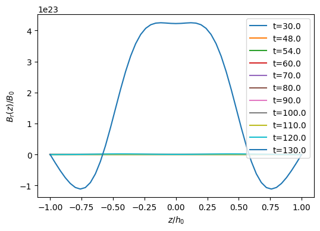

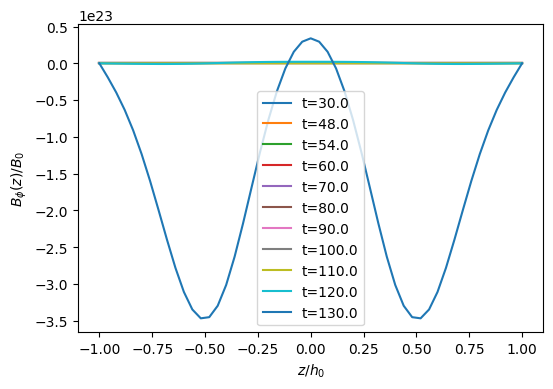

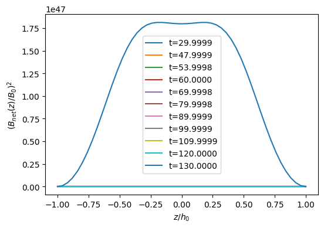

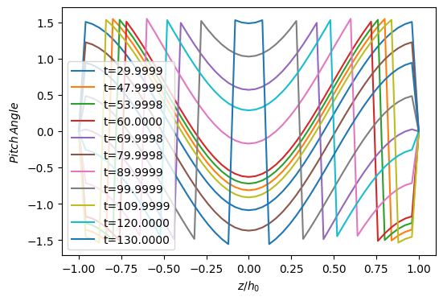

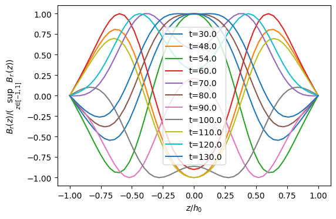

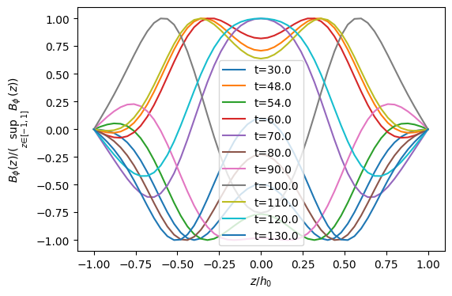

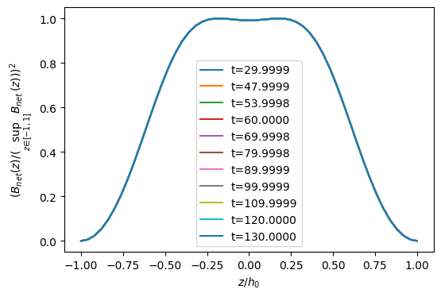

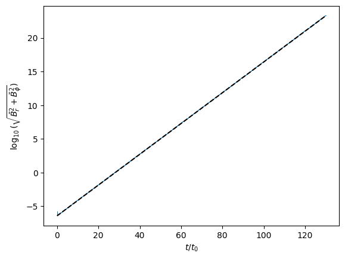

```python
run(B,iterations_to_save,B_list,B_time,B_pitch,dz,Nz,5.5,0)
plot(iterations_to_save,B_list,B_time,B_pitch,Nz)
```

# Example-2 ($\alpha-\Omega$ dynamo)

```
The Decay rate is [1.3238099]
```

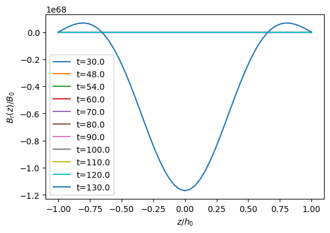

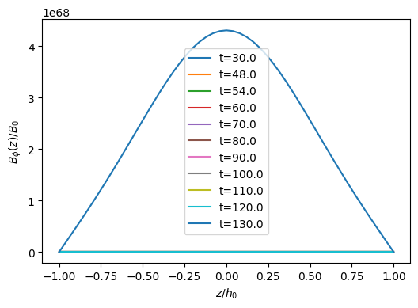

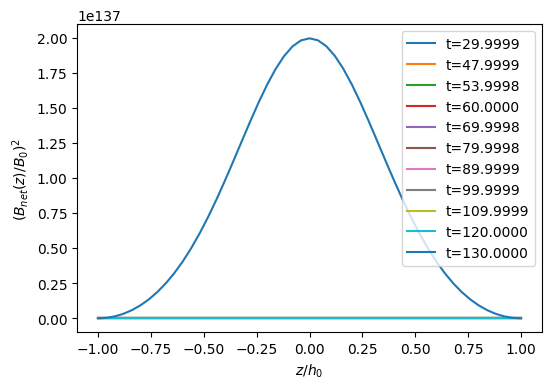

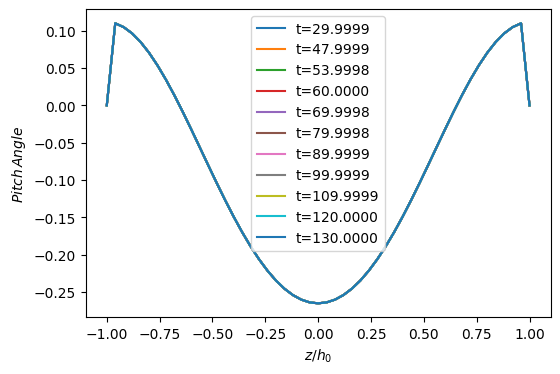

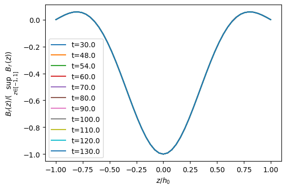

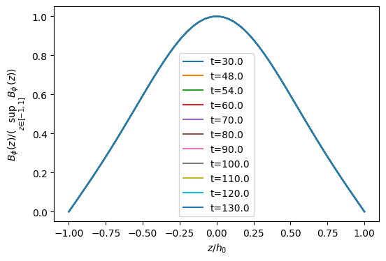

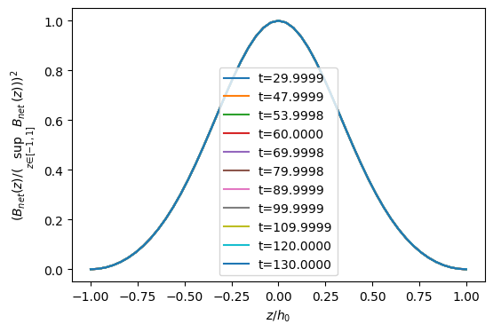

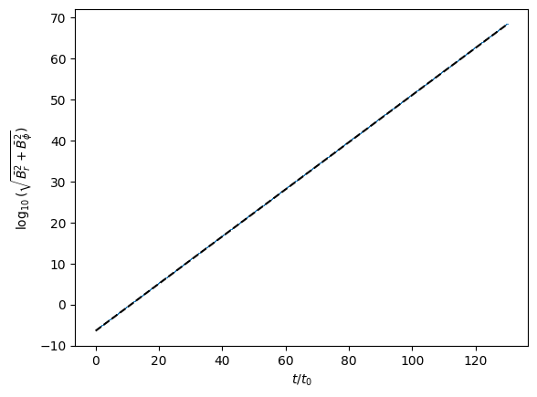

```python
run(B,iterations_to_save,B_list,B_time,B_pitch,dz,Nz,1,-20)
plot(iterations_to_save,B_list,B_time,B_pitch,Nz)
```

# Example-3 ($\alpha^2$ dynamo)

```
The Decay rate is [-0.01868444]
```

[figure not shown]

[figure not shown]

[figure not shown]

[figure not shown]

[figure not shown]

```python
run(B,iterations_to_save,B_list,B_time,B_pitch,dz,Nz,8,0)
plot(iterations_to_save,B_list,B_time,B_pitch,Nz)
```

```
The Decay rate is [0.77744216]
```

[figure not shown]

[figure not shown]

[figure not shown]

[figure not shown]

[figure not shown]

```python
run(B,iterations_to_save,B_list,B_time,B_pitch,dz,Nz,9,0)
plot(iterations_to_save,B_list,B_time,B_pitch,Nz)
```